# Data Pre-processing

Carlos Calvo Hernandez

3/29/2019

## Data Pre-processing

Real datasets often come with missing values. In R, these should be encoded using `NA`. There are basically two approaches to deal with such cases.

- Drop the observations with missing values, or, if one feature contains a very high proportion of NAs, drop the feature altogether. These approaches are only applicable when the proportion of missing values is relatively small. Otherwise, it could lead to loosing too much data.
- Impute missing values.

Data imputation can however have critical consequences depending on the proportion of missing values and their nature. From a statistical point of view, missing values are classified as missing completely at random (MCAR), missing at random (MAR) or missing not at random (MNAR), and the type of the missing values will influence the efficiency of the imputation method.

The figure below shows how different imputation methods perform depending on the proportion and nature of missing values

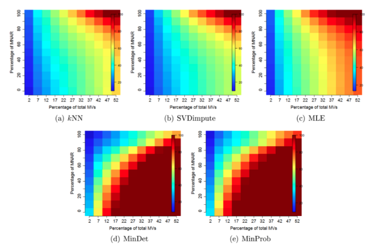

Normalised RMSE describing the effect of different imputation methods depending on the nature and proportion of the missing values

### Dataport Data

*Let’s use some of the Dataport data to see how to impute missing values*

First step, access the Dataport database as we have done in the past and then collect a small database for our testing.

```r
weather_db <- tbl(con, in_schema("university", "weather"))
```

```r
(hours_db <- tbl(con, in_schema("university", "electricity_egauge_hours")))
```

```
## # Source:   table<university.electricity_egauge_hours> [?? x 69]
## # Database: postgres 9.5.16 [Vr5SmRn96HF5@dataport.cloud:5434/postgres]
##    dataid localhour             use   air1  air2  air3 airwindowunit1
##     <int> <dttm>              <dbl>  <dbl> <dbl> <dbl>          <dbl>
##  1     22 2013-06-22 17:00:00 0.725 0.444     NA    NA             NA
##  2     22 2013-06-22 18:00:00 1.25  0.739     NA    NA             NA
##  3     22 2013-06-22 19:00:00 0.842 0.529     NA    NA             NA
##  4     22 2013-06-22 20:00:00 0.726 0.389     NA    NA             NA
##  5     22 2013-06-22 21:00:00 0.884 0.388     NA    NA             NA
##  6     22 2013-06-22 22:00:00 0.776 0.231     NA    NA             NA
##  7     22 2013-06-22 23:00:00 0.628 0.291     NA    NA             NA
##  8     22 2013-06-23 00:00:00 0.408 0.201     NA    NA             NA
##  9     22 2013-06-23 01:00:00 0.226 0.0856    NA    NA             NA
## 10     22 2013-06-23 02:00:00 0.248 0.0864    NA    NA             NA
## # … with more rows, and 62 more variables: aquarium1 <dbl>,
## #   bathroom1 <dbl>, bathroom2 <dbl>, bedroom1 <dbl>, bedroom2 <dbl>,
## #   bedroom3 <dbl>, bedroom4 <dbl>, bedroom5 <dbl>, car1 <dbl>,
## #   clotheswasher1 <dbl>, clotheswasher_dryg1 <dbl>, diningroom1 <dbl>,
## #   diningroom2 <dbl>, dishwasher1 <dbl>, disposal1 <dbl>, drye1 <dbl>,
## #   dryg1 <dbl>, freezer1 <dbl>, furnace1 <dbl>, furnace2 <dbl>,
## #   garage1 <dbl>, garage2 <dbl>, gen <dbl>, grid <dbl>, heater1 <dbl>,
## #   housefan1 <dbl>, icemaker1 <dbl>, jacuzzi1 <dbl>, kitchen1 <dbl>,
## #   kitchen2 <dbl>, kitchenapp1 <dbl>, kitchenapp2 <dbl>,
## #   lights_plugs1 <dbl>, lights_plugs2 <dbl>, lights_plugs3 <dbl>,
## #   lights_plugs4 <dbl>, lights_plugs5 <dbl>, lights_plugs6 <dbl>,
## #   livingroom1 <dbl>, livingroom2 <dbl>, microwave1 <dbl>, office1 <dbl>,
## #   outsidelights_plugs1 <dbl>, outsidelights_plugs2 <dbl>, oven1 <dbl>,
## #   oven2 <dbl>, pool1 <dbl>, pool2 <dbl>, poollight1 <dbl>,
## #   poolpump1 <dbl>, pump1 <dbl>, range1 <dbl>, refrigerator1 <dbl>,
## #   refrigerator2 <dbl>, security1 <dbl>, shed1 <dbl>, sprinkler1 <dbl>,
## #   utilityroom1 <dbl>, venthood1 <dbl>, waterheater1 <dbl>,
## #   waterheater2 <dbl>, winecooler1 <dbl>
```

```r
(temp_db <- tbl(con, in_schema("university", "indoor_temperature_sensor")))
```

```
## # Source:   table<university.indoor_temperature_sensor> [?? x 4]
## # Database: postgres 9.5.16 [Vr5SmRn96HF5@dataport.cloud:5434/postgres]
##    dataid localminute         temp_f temp_c
##     <int> <dttm>               <dbl>  <dbl>
##  1   8600 2014-11-25 22:22:01   61.6   16.4
##  2   8600 2014-11-25 22:23:02   61.6   16.4
##  3   8600 2014-11-25 22:24:01   61.6   16.4
##  4   8600 2014-11-25 22:25:01   61.6   16.4
##  5   8600 2014-11-25 22:26:01   61.6   16.4
##  6   8600 2014-11-25 22:27:02   61.6   16.4
##  7   8600 2014-11-25 22:28:01   61.6   16.4
##  8   8600 2014-11-25 22:29:09   61.6   16.4
##  9   8600 2014-11-25 22:30:02   61.6   16.4
## 10   8600 2014-11-25 22:31:01   61.6   16.4
## # … with more rows
```

Let’s select every observation in these data sets from a week in January 2016, (5-12).

```r
hours <- hours_db %>%
  filter( localhour < "2016-01-13 00:00:00" & localhour > "2016-01-05 00:00:00") %>%
  collect()
```

*Since the ‘indoor temperature sensor’ is in minute increments we need to aggregate into hour increments so this is compatible with the electricty and weather data.*

```r
temp <- temp_db %>%
  filter( localminute < "2016-01-13 00:00:00" & localminute > "2016-01-05 00:00:00") %>%
  collect() %>%
  mutate(localhour = floor_date(localminute, "hour")) %>%
  group_by(dataid, localhour) %>%
  summarise(temp_f = mean(temp_f), temp_c = mean(temp_c))
```

```r
weather <- weather_db %>%
  filter( localhour < "2016-01-13 00:00:00" & localhour > "2016-01-05 00:00:00") %>%
  collect()
```

Now, merge the three data sets into one to test the data

```r
dataport <- left_join(hours, weather, by = c("localhour"))
dataport <- left_join(dataport, temp, by = c("dataid", "localhour"))
```

Let’s check for missing values

```r
dataport_count <- dataport %>%
  select(everything()) %>%
  summarise_all(funs(sum(is.na(.))))
dataport_count
```

```
## # A tibble: 1 x 98
##   dataid localhour   use  air1   air2   air3 airwindowunit1 aquarium1
##    <int>     <int> <int> <int>  <int>  <int>          <int>     <int>
## 1      0         0  4011 65919 250944 290820         293112    294831
## # … with 90 more variables: bathroom1 <int>, bathroom2 <int>,
## #   bedroom1 <int>, bedroom2 <int>, bedroom3 <int>, bedroom4 <int>,
## #   bedroom5 <int>, car1 <int>, clotheswasher1 <int>,
## #   clotheswasher_dryg1 <int>, diningroom1 <int>, diningroom2 <int>,
## #   dishwasher1 <int>, disposal1 <int>, drye1 <int>, dryg1 <int>,
## #   freezer1 <int>, furnace1 <int>, furnace2 <int>, garage1 <int>,
## #   garage2 <int>, gen <int>, grid <int>, heater1 <int>, housefan1 <int>,
## #   icemaker1 <int>, jacuzzi1 <int>, kitchen1 <int>, kitchen2 <int>,
## #   kitchenapp1 <int>, kitchenapp2 <int>, lights_plugs1 <int>,
## #   lights_plugs2 <int>, lights_plugs3 <int>, lights_plugs4 <int>,
## #   lights_plugs5 <int>, lights_plugs6 <int>, livingroom1 <int>,
## #   livingroom2 <int>, microwave1 <int>, office1 <int>,
## #   outsidelights_plugs1 <int>, outsidelights_plugs2 <int>, oven1 <int>,
## #   oven2 <int>, pool1 <int>, pool2 <int>, poollight1 <int>,
## #   poolpump1 <int>, pump1 <int>, range1 <int>, refrigerator1 <int>,
## #   refrigerator2 <int>, security1 <int>, shed1 <int>, sprinkler1 <int>,
## #   utilityroom1 <int>, venthood1 <int>, waterheater1 <int>,
## #   waterheater2 <int>, winecooler1 <int>, latitude <int>,
## #   longitude <int>, tz_offset <int>, summary <int>, ozone <int>,
## #   ozone_error <int>, temperature <int>, temperature_error <int>,
## #   dew_point <int>, dew_point_error <int>, humidity <int>,
## #   humidity_error <int>, visibility <int>, visibility_error <int>,
## #   apparent_temperature <int>, apparent_temperature_error <int>,
## #   pressure <int>, pressure_error <int>, wind_speed <int>,
## #   wind_speed_error <int>, cloud_cover <int>, cloud_cover_error <int>,
## #   wind_bearing <int>, precip_intensity <int>,
## #   precip_intensity_error <int>, precip_probability <int>,
## #   precip_type <int>, temp_f <int>, temp_c <int>
```

There’s three ways of specifying the components of a model in the `train` function. One, using a full formula (i.e. lm: y ~ x1… ). Two, using the `X`/ `Y` predictors/target variable split and letting `caret`do the rest, and three, using a recipe from the `recipes` package[^1].

Let’s separate by target variable and predictors

```r
Y <- dataport$use # target variable
X <- select(dataport, -c(use, diningroom2, pool2, ozone_error, temperature_error, dew_point_error, humidity_error, visibility_error, apparent_temperature_error, pressure_error, wind_speed_error, cloud_cover_error, precip_intensity_error)) # predictors that have any non-missing values
```

```r
try(train(X, Y))
```

[output not shown]

(Note that the occurrence of the error will depend on the model chosen.)

We could perform imputation manually, but `caret` provides a whole range of pre-processing methods, including imputation methods, that can directly be passed when training the model.

#### Median Imputation

*Imputation using median of features. This methods works well if the data are missing at random.*

```r
 try(train(X, Y, preProcess = "medianImpute"))
```

How things should work:

```r
data(mtcars)
mtcars[sample(nrow(mtcars), 10), "hp"] <- NA
B <- mtcars$mpg    # target variable
A <- mtcars[, 2:4] # predictors
```

```r
try(train(A, B))
```

```
## Something is wrong; all the RMSE metric values are missing:
##       RMSE        Rsquared        MAE
##  Min.   : NA   Min.   : NA   Min.   : NA
##  1st Qu.: NA   1st Qu.: NA   1st Qu.: NA
##  Median : NA   Median : NA   Median : NA
##  Mean   :NaN   Mean   :NaN   Mean   :NaN
##  3rd Qu.: NA   3rd Qu.: NA   3rd Qu.: NA
##  Max.   : NA   Max.   : NA   Max.   : NA
##  NA's   :2     NA's   :2     NA's   :2
## Error : Stopping
```

```r
try(train(A, B, preProcess = "medianImpute"))
```

```
## Random Forest
##
## 32 samples
##  3 predictor
##
## Pre-processing: median imputation (3)
## Resampling: Bootstrapped (25 reps)
## Summary of sample sizes: 32, 32, 32, 32, 32, 32, ...
## Resampling results across tuning parameters:
##
##   mtry  RMSE      Rsquared   MAE
##   2     2.534795  0.8358855  2.046411
##   3     2.580800  0.8289918  2.075420
##
## RMSE was used to select the optimal model using the smallest value.
## The final value used for the model was mtry = 2.
```

#### kNN Imputations

If there is a systematic bias in the missing values, then median imputation is known to produce incorrect results. kNN imputation will impute missing values using on other, similar non-missing rows. The default value is 5.

```r
train(A, B, preProcess = "knnImpute")
```

```
## Random Forest
##
## 32 samples
##  3 predictor
##
## Pre-processing: nearest neighbor imputation (3), centered (3), scaled (3)
## Resampling: Bootstrapped (25 reps)
## Summary of sample sizes: 32, 32, 32, 32, 32, 32, ...
## Resampling results across tuning parameters:
##
##   mtry  RMSE      Rsquared   MAE
##   2     2.550146  0.8364635  2.116999
##   3     2.590537  0.8305485  2.135847
##
## RMSE was used to select the optimal model using the smallest value.
## The final value used for the model was mtry = 2.
```

## What to do with our data?

### Zero- and Near zero-variance predictors

Let’s start by dealing with the predictors that only have a single unique value (i.e. a “zero-variance predictor”). The concern here that these predictors may become zero-variance predictors when the data are split into cross-validation/bootstrap sub-samples or that a few samples may have an undue influence on the model. These “near-zero-variance” predictors may need to be identified and eliminated prior to modeling.

To identify these types of predictors, the following two metrics can be calculated:

- the frequency of the most prevalent value over the second most frequent value (called the “frequency ratio’’), which would be near one for well-behaved predictors and very large for highly-unbalanced data and
- the “percent of unique values’’ is the number of unique values divided by the total number of samples (times 100) that approaches zero as the granularity of the data increases.

We would not want to falsely identify data that have low granularity but are evenly distributed, such as data from a discrete uniform distribution. Using both criteria should not falsely detect such predictors.

The `nearZeroVar` function can be used to identify near zero-variance variables (the `saveMetrics` argument can be used to show the details and usually defaults to `FALSE`):

```r
nzv <- nearZeroVar(dataport, saveMetrics= TRUE)
nzv[nzv$nzv,]
```

```
##                      freqRatio percentUnique zeroVar  nzv
## air1                  81.41166   2.574778947   FALSE TRUE
## air2                  73.76636   0.980690850   FALSE TRUE
## air3                  86.60000   0.186185698   FALSE TRUE
## airwindowunit1       759.00000   0.002031117   FALSE TRUE
## bathroom1             19.44792   0.964441917   FALSE TRUE
## bathroom2             30.05000   0.236963616   FALSE TRUE
## bedroom5              67.00000   0.019295609   FALSE TRUE
## car1                  32.17794   0.894706910   FALSE TRUE
## clotheswasher1        80.83983   1.108312684   FALSE TRUE
## diningroom1           19.42520   0.374741033   FALSE TRUE
## dishwasher1          132.47988   1.118468267   FALSE TRUE
## disposal1            134.83140   0.219360604   FALSE TRUE
## drye1                 72.77254   1.233564881   FALSE TRUE
## dryg1                 51.93902   0.354091346   FALSE TRUE
## freezer1             226.50000   0.590716443   FALSE TRUE
## heater1               74.80000   0.236286577   FALSE TRUE
## housefan1             45.12500   0.033174906   FALSE TRUE
## icemaker1             21.11111   0.167567128   FALSE TRUE
## jacuzzi1              21.69841   0.612381687   FALSE TRUE
## kitchenapp2           25.53420   1.514874545   FALSE TRUE
## lights_plugs1         24.47426   2.603214581   FALSE TRUE
## lights_plugs5         29.40000   0.139470014   FALSE TRUE
## outsidelights_plugs1  41.49206   0.641155841   FALSE TRUE
## pool1                 89.00000   0.066688332   FALSE TRUE
## poollight1           280.50000   0.003723714   FALSE TRUE
## pump1                 39.38889   0.075489838   FALSE TRUE
## range1                33.42525   0.761330246   FALSE TRUE
## refrigerator1         31.85714   4.308675576   FALSE TRUE
## refrigerator2         64.28571   1.257261242   FALSE TRUE
## waterheater1         122.73333   1.084277803   FALSE TRUE
## waterheater2          24.08333   0.052809034   FALSE TRUE
## visibility            33.07999   0.073797240   FALSE TRUE
## precip_intensity      81.62873   0.041299373   FALSE TRUE
## precip_probability    37.17331   0.022680803   FALSE TRUE
```

If we compare the dimension of our original data and of our near zero-variance data we can see they’re compatible

```r
dim(dataport)
```

[output not shown]

```r
nzv <- nearZeroVar(dataport)
filteredDescr <- dataport[, -nzv]
dim(filteredDescr)
```

```
## [1] 295404     52
```

By default, `nearZeroVar` will return the positions of the variables that are flagged to be problematic.

### The `preProcess` function

The `preProcess` class can be used for many operations on predictors, including centering and scaling. The function `preProcess` estimates the required parameters for each operation and `predict.preProcess` is used to apply them to specific data sets. As we saw, this function can also be interfaced when calling the `train` function.

Note that, in all cases of pre-processing, the `preProcess` function estimates whatever it requires from a specific data set (e.g. the training set) and then applies these transformations to any data set without recomputing the values

```r
preProc <- preProcess(filteredDescr, method = c("center", "scale", "medianImpute"))
predicted <- predict(preProc, newdata = filteredDescr)
```

Again, we’ll check that all missing valued were imputed in the step before

```r
predicted_na <- predicted %>%
  select(everything()) %>%
  summarise_all(funs(sum(is.na(.))))
predicted_na
```

```
## # A tibble: 1 x 52
##   dataid localhour   use aquarium1 bedroom1 bedroom2 bedroom3 bedroom4
##    <int>     <int> <int>     <int>    <int>    <int>    <int>    <int>
## 1      0         0     0         0        0        0        0        0
## # … with 44 more variables: clotheswasher_dryg1 <int>, furnace1 <int>,
## #   furnace2 <int>, garage1 <int>, garage2 <int>, gen <int>, grid <int>,
## #   kitchen1 <int>, kitchen2 <int>, kitchenapp1 <int>,
## #   lights_plugs2 <int>, lights_plugs3 <int>, lights_plugs4 <int>,
## #   lights_plugs6 <int>, livingroom1 <int>, livingroom2 <int>,
## #   microwave1 <int>, office1 <int>, outsidelights_plugs2 <int>,
## #   oven1 <int>, oven2 <int>, poolpump1 <int>, security1 <int>,
## #   shed1 <int>, sprinkler1 <int>, utilityroom1 <int>, venthood1 <int>,
## #   winecooler1 <int>, latitude <int>, longitude <int>, tz_offset <int>,
## #   summary <int>, ozone <int>, temperature <int>, dew_point <int>,
## #   humidity <int>, apparent_temperature <int>, pressure <int>,
## #   wind_speed <int>, cloud_cover <int>, wind_bearing <int>,
## #   precip_type <int>, temp_f <int>, temp_c <int>
```

Our final model is:

```r
predicted <- select(predicted, -precip_type) # since precipitation type still has missing values let's just remove it
train(use ~ . , predicted, method = "lm")
```

[output not shown]

[output cut: 19 more lines]

[output not shown]

```
## Linear Regression
##
## 295404 samples
##     50 predictor
##
## No pre-processing
## Resampling: Bootstrapped (25 reps)
## Summary of sample sizes: 295404, 295404, 295404, 295404, 295404, 295404, ...
## Resampling results:
##
##   RMSE       Rsquared  MAE
##   0.5477522  0.695013  0.2713868
##
## Tuning parameter 'intercept' was held constant at a value of TRUE
```

[^1]: Check the [caret](https://topepo.github.io/caret/) and recipes packages documentation.